# Part II - ETUDE SUR LA RENTABILITE DES PRETS BANCAIRES

## Par Armel Elysé TITIL BASSOCK

## RESUME

> Un pret est le fait pour un établissement de crédit, de proposer une solution de financement, en mettant à disposition des fonds à un bénéficiaire, sans en exiger le remboursement immédiat. Dans ce document, nous allons étudier un ensemble de données de pret, fournit par Prosper.

> Ce jeu de données comprend un ensemble 113 937 prêts avec 81 variables sur chaque prêt, y compris le montant du prêt, le taux de l'emprunteur (ou taux d'intérêt), le statut actuel du prêt, le revenu de l'emprunteur, et bien d'autres.

> **Exploitation**: Dans le but de retirer des informations utiles de ce jeu de données, nous nous posons les questions suivantes :᷆
> - Quels facteurs affectent le statut du résultat d'un pret ?
> - QU'est ce qui affecte l'APR ou le taux d̀intéret de l'emprunteur ?
> - Existe-t-il des différences entre les prets en fonction de l'importance du montant initialement emprunté ?

Afin de repondre a ces questions, nous avons exploré notre dataset à travers plusieurs caractéristiques. Les caracteristiques d'interet principales étant :

> - LoanStatus -- statut du pret
> - BorrowerAPR -- taux annuel effectif global de l'emprunteur
> - BorrowerRate -- Taux d'interet de l'emprunt pour ce pret
> - LenderYield -- Rendement du preteur
> - LoanOriginalAmount -- montant initial du pret

|  | ListingKey | ListingNumber | ListingCreationDate | Term | LoanStatus | BorrowerAPR | BorrowerRate | LenderYield | EstimatedEffectiveYield | EstimatedLoss | ... | LP_NetPrincipalLoss | LP_NonPrincipalRecoverypayments | PercentFunded | Recommendations | InvestmentFromFriendsCount | InvestmentFromFriendsAmount | Investors | CreditRating | AnyProsper | ListingCategory |
| --- | --- | --- | --- | --- | --- | --- | --- | --- | --- | --- | --- | --- | --- | --- | --- | --- | --- | --- | --- | --- | --- |
| 0 | 1021339766868145413AB3B | 193129 | 2007-08-26 19:09:29.263 | 36 | Completed | 0.16516 | 0.1580 | 0.1380 | NaN | NaN | ... | 0.0 | 0.0 | 1.0 | 0 | 0 | 0.0 | 258 | C | False | Non disponible |
| 1 | 10273602499503308B223C1 | 1209647 | 2014-02-27 08:28:07.900 | 36 | Current | 0.12016 | 0.0920 | 0.0820 | 0.07960 | 0.0249 | ... | 0.0 | 0.0 | 1.0 | 0 | 0 | 0.0 | 1 | A | False | amelioration de habitat |
| 2 | 0EE9337825851032864889A | 81716 | 2007-01-05 15:00:47.090 | 36 | Completed | 0.28269 | 0.2750 | 0.2400 | NaN | NaN | ... | 0.0 | 0.0 | 1.0 | 0 | 0 | 0.0 | 41 | HR | False | Non disponible |
| 3 | 0EF5356002482715299901A | 658116 | 2012-10-22 11:02:35.010 | 36 | Current | 0.12528 | 0.0974 | 0.0874 | 0.08490 | 0.0249 | ... | 0.0 | 0.0 | 1.0 | 0 | 0 | 0.0 | 158 | A | False | moto |
| 4 | 0F023589499656230C5E3E2 | 909464 | 2013-09-14 18:38:39.097 | 36 | Current | 0.24614 | 0.2085 | 0.1985 | 0.18316 | 0.0925 | ... | 0.0 | 0.0 | 1.0 | 0 | 0 | 0.0 | 20 | D | True | amelioration de habitat |

5 rows × 67 columns

## Visualisation 1

> En étudiant les paramètres de notre jeu de données en fonction de leur fréquences, nous avons déterminé que la tranche de revenus est une caractéristique d'intéret pour notre étude. Nous essayons de déterminer quels sont les tranches de revenus qui demandent le plus de pret.

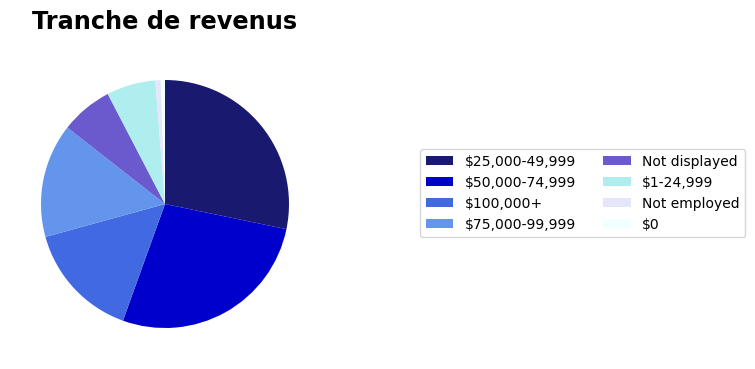

> On constate que les personnes à revenus moyen donc compris entre **25 000 et 75 000 dollars** sont les plus demandeuses de pret.

## Visualisation 2

> Partant du constat précédemment effectué, nous observons la fréquence des status de pret en fonction des différentes tranches de revenus. Nous essayons de déterminer quels sont les tranches de revenus dont les prets sont en cours de rembousement ou ont déjà été remboursés.

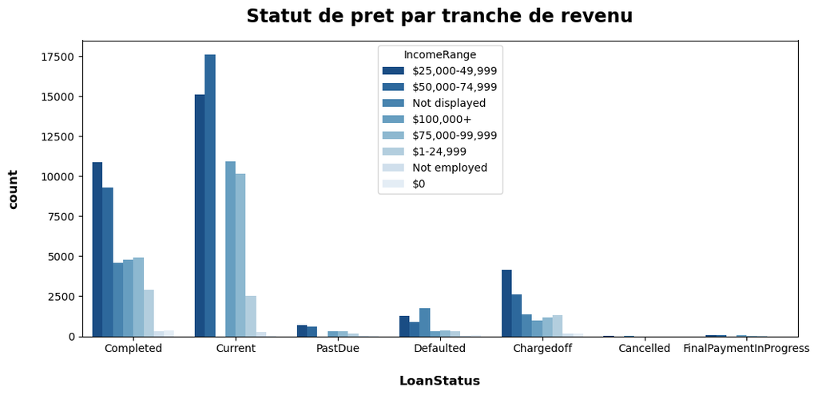

> On constate également que ces tranches de revenus sont de loin les plus présente dans les catégories de pret complétés ou en cours de remboursement.

## Visualisation 3

> Nous avons fait une observation du statut d̀un pret en fonction du taux annuel attribué à l'emprunteur ainsi que sa profession. Ce visuel a pour but de déterminer si la ou les professions qui pouraient avoir une revalorisation de leur taux.

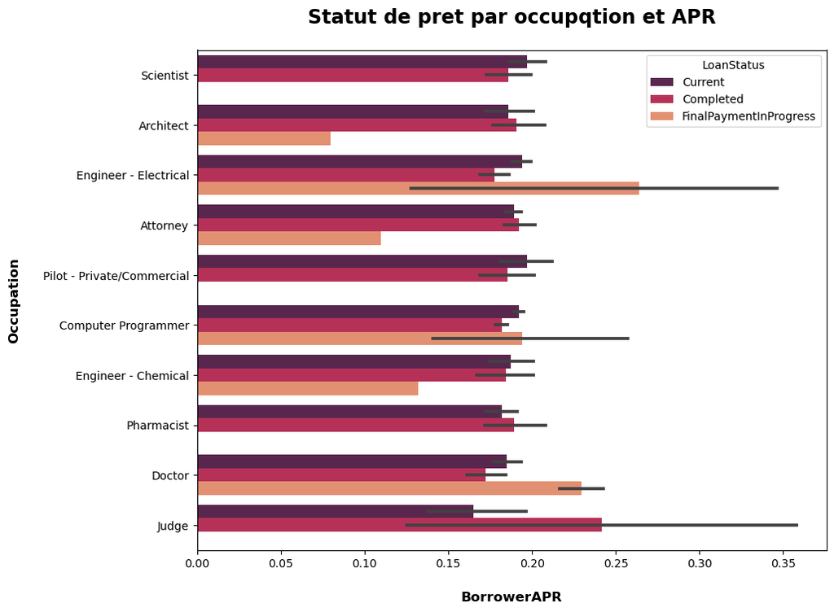